# RL models comparison

The behavior in the machine game task lends itself to prediction error modeling as frequently done in the literature.

In this approach the probability of playing a machine is modeled as:

$p(k_{t} = 1) = \frac{e^{\beta*(EV_t)}}{1+e^{\beta*(EV_t)}}$

where the $EV_t$ is updated after observing the reward ($r$) in each trial at a learning rate ($\alpha$) by a prediction error that can be distorted non-linearly by an exponent ($\gamma$)

${EV_{t+1}} = {EV_t} + \alpha * (r - {EV_t})^\gamma$

The parameters of the model are:

- $\alpha$ - learning rate. Higher values mean faster learning. Can be allowed to vary for gains and losses as $\alpha_{pos}$ and $\alpha_{neg}$
- $\gamma$ - value concavity exponent. Higher values mean less distortion of prediction error. Can be omitted (i.e. fixed to 1) and allowed to vary for gains and losses as $exp_{pos}$ and $exp_{neg}$
- $\beta$ - inverse temperature. Higher values mean subjects are choosing based on expected value, lower means the choice is driven less by EV and more by random guessing (for $\beta = 0$ all choices are equally likely).

To determine the best model we ran models where these parameters were allowed to vary for gains and losses and were either estimated for each subject.

Each model was fit 50 times for each subject minimizing negative log probability.

## Model comparison

Fit quality can be assesed in several ways. We chose to do this by fitting the models on %75 of each subject’ data and then predicting the left out 25% with the best fitting parameters for each model. The predicted choice accuracy of this left out data was out metric to determine the best model.

```r
mean_pred_df = ave_sub_preds %>%
  group_by(model) %>%
  summarise(ave_pred_prop = mean(cor_pred_prop),
            sem_pred_prop = sem(cor_pred_prop)) %>%
  left_join(num_pars_df %>%
              mutate(model = gsub("LearningParams_", "", model)) %>%
              select(-pars),
            by="model") %>%
  mutate(x_axis = factor(x_axis, levels=unique(x_axis[order(ave_pred_prop, x_axis)]), ordered=TRUE),
         pred_order = as.numeric(x_axis))
```

Plotting each model’s prediction accuracy when predicting the quarter of left out data for each subject after fitting the model on the remaining three quarters of data.

Model are listed from worst to best.

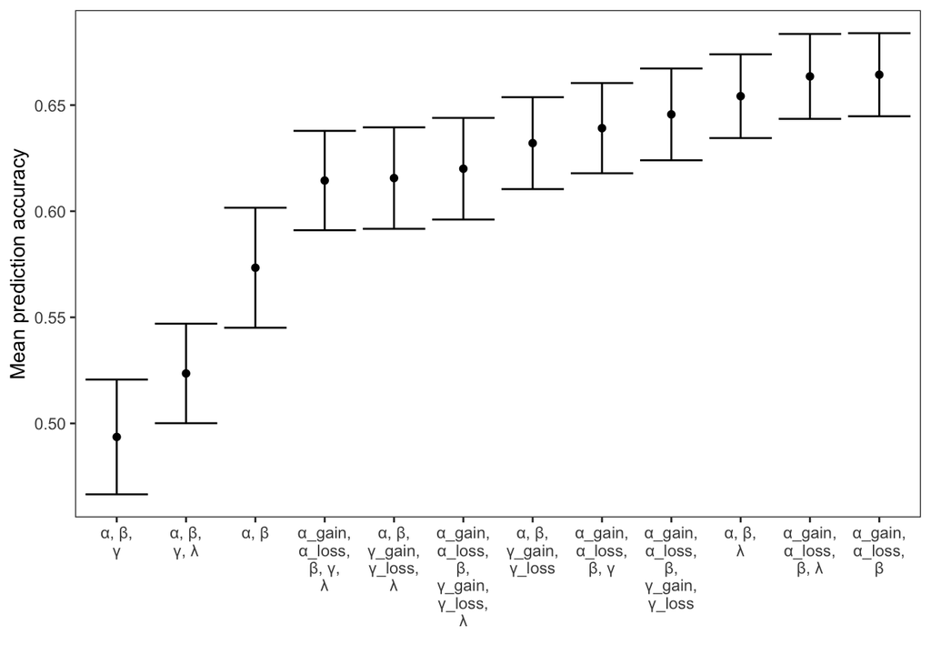

```r
mean_pred_df %>%
  ggplot(aes(x_axis, ave_pred_prop))+
  geom_point()+
  geom_errorbar(aes(ymin = ave_pred_prop-sem_pred_prop, ymax = ave_pred_prop+sem_pred_prop))+
  xlab("")+
  ylab("Mean prediction accuracy")+
  scale_x_discrete(labels = function(x) str_wrap(x, width=5))+
  theme(legend.position = "none",
        panel.grid = element_blank())
```

```r
ggsave("RL_models_comp_pred.jpeg", device = "jpeg", path = fig_path, width = 7, height = 5, units = "in", dpi = 450)
```

```r
tmp = with(ave_sub_preds, pairwise.t.test(cor_pred_prop, model), p.adj="fdr")
tmp = data.frame(tmp$p.value)
tmp = tmp %>%
  mutate(model1 = row.names(tmp)) %>%
  gather(model2, p_value, -model1) %>%
  mutate(model2 = gsub('\\.', '-', model2)) %>%
  filter(p_value <0.05) %>%
  arrange(model1)

tmp
```

| model1 | model2 | p_value |
| --- | --- | --- |
| Fit_alpha-beta-exp_Fix_lossave_ | Fit_alpha_neg-alpha_pos-beta_Fix_exp-lossave_ | 1.159887e-05 |
| Fit_alpha-beta-exp_Fix_lossave_ | Fit_alpha_neg-alpha_pos-beta-exp_Fix_lossave_ | 5.028357e-04 |
| Fit_alpha-beta-exp_Fix_lossave_ | Fit_alpha_neg-alpha_pos-beta-exp_neg-exp_pos_Fix_lossave_ | 2.162025e-04 |
| Fit_alpha-beta-exp_Fix_lossave_ | Fit_alpha_neg-alpha_pos-beta-exp_neg-exp_pos-lossave_Fix_ | 6.242266e-03 |
| Fit_alpha-beta-exp_Fix_lossave_ | Fit_alpha_neg-alpha_pos-beta-exp-lossave_Fix_ | 1.111002e-02 |
| Fit_alpha-beta-exp_Fix_lossave_ | Fit_alpha_neg-alpha_pos-beta-lossave_Fix_exp_ | 1.426577e-05 |
| Fit_alpha-beta-exp_neg-exp_pos_Fix_lossave_ | Fit_alpha-beta-exp_Fix_lossave_ | 1.356126e-03 |
| Fit_alpha-beta-exp_neg-exp_pos-lossave_Fix_ | Fit_alpha-beta-exp_Fix_lossave_ | 1.042329e-02 |
| Fit_alpha-beta-exp-lossave_Fix_ | Fit_alpha_neg-alpha_pos-beta_Fix_exp-lossave_ | 9.591582e-04 |
| Fit_alpha-beta-exp-lossave_Fix_ | Fit_alpha_neg-alpha_pos-beta-exp_Fix_lossave_ | 2.026348e-02 |

[output cut: 5 more lines]

### Learner group difference in fit

Are there any models that show a difference between the learner groups that survives multiple comparison? Yes.

```r
models = unique(ave_sub_preds$model)

out_df = data.frame(model=NA, learner_p = NA)
for(m in models){
  reg_out = summary(lm(cor_pred_prop ~ learner, ave_sub_preds %>% filter(model == m)))
  learner_p = coef(reg_out)["learner","Pr(>|t|)"]
  cur_row = data.frame(model = m, learner_p = learner_p)
  out_df = rbind(out_df, cur_row)
}
out_df = out_df[-1,]
out_df = out_df %>%
  mutate(learner_p = p.adjust(learner_p, method="fdr"))%>%
  filter(learner_p<0.05)
out_df
```

| model | learner_p |
| --- | --- |
| Fit_alpha_neg-alpha_pos-beta_Fix_exp-lossave_ | 2.388837e-05 |
| Fit_alpha_neg-alpha_pos-beta-exp_Fix_lossave_ | 1.035275e-04 |
| Fit_alpha_neg-alpha_pos-beta-exp_neg-exp_pos_Fix_lossave_ | 9.040939e-05 |
| Fit_alpha_neg-alpha_pos-beta-exp_neg-exp_pos-lossave_Fix_ | 1.347270e-04 |
| Fit_alpha_neg-alpha_pos-beta-exp-lossave_Fix_ | 4.329310e-04 |
| Fit_alpha_neg-alpha_pos-beta-lossave_Fix_exp_ | 4.489486e-04 |
| Fit_alpha-beta_Fix_exp-lossave_ | 1.195114e-07 |
| Fit_alpha-beta-exp_Fix_lossave_ | 4.329310e-04 |
| Fit_alpha-beta-exp_neg-exp_pos_Fix_lossave_ | 4.944618e-05 |
| Fit_alpha-beta-exp_neg-exp_pos-lossave_Fix_ | 6.037535e-04 |

[output cut: 1 more lines]

What direction are the learner group differences in? Prediction accuracies are consistently higher for learners compared to non-learners.

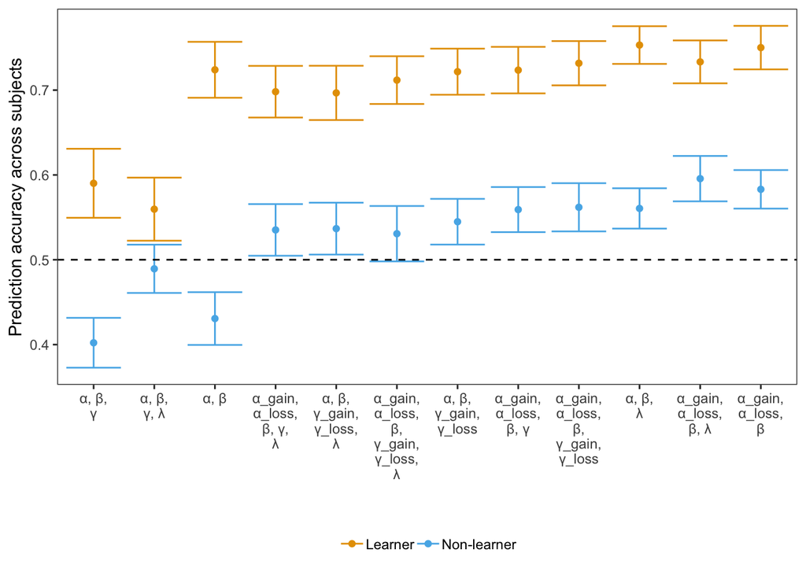

```r
ave_sub_preds %>%
  filter(!is.na(learner)) %>%
  group_by(learner, model) %>%
  summarise(ave_pred_prop = mean(cor_pred_prop),
            sem_pred_prop = sem(cor_pred_prop)) %>%
  left_join(num_pars_df %>%
              mutate(model = gsub("LearningParams_", "", model)) %>%
              select(-pars),
            by="model") %>%
  left_join(mean_pred_df %>%
              select(model, pred_order), by="model") %>%
  ungroup()%>%
  mutate(x_axis = factor(x_axis, levels=unique(x_axis[order(pred_order, x_axis)]), ordered=TRUE),
         learner = ifelse(learner == 1, "Learner", "Non-learner")) %>%
  ggplot(aes(factor(x_axis),ave_pred_prop, color=factor(learner)))+
  geom_point()+
  geom_errorbar(aes(ymin = ave_pred_prop-sem_pred_prop, ymax = ave_pred_prop+sem_pred_prop))+
  xlab("")+
  ylab("Prediction accuracy across subjects")+
  theme(panel.grid = element_blank(),
        legend.title = element_blank())+
  scale_x_discrete(labels = function(x) str_wrap(x, width=5))+
  geom_hline(yintercept = 0.5, linetype="dashed")
```

```r
ggsave("RL_models_comp_learner_pred.jpeg", device = "jpeg", path = fig_path, width = 7, height = 5, units = "in", dpi = 450)
```

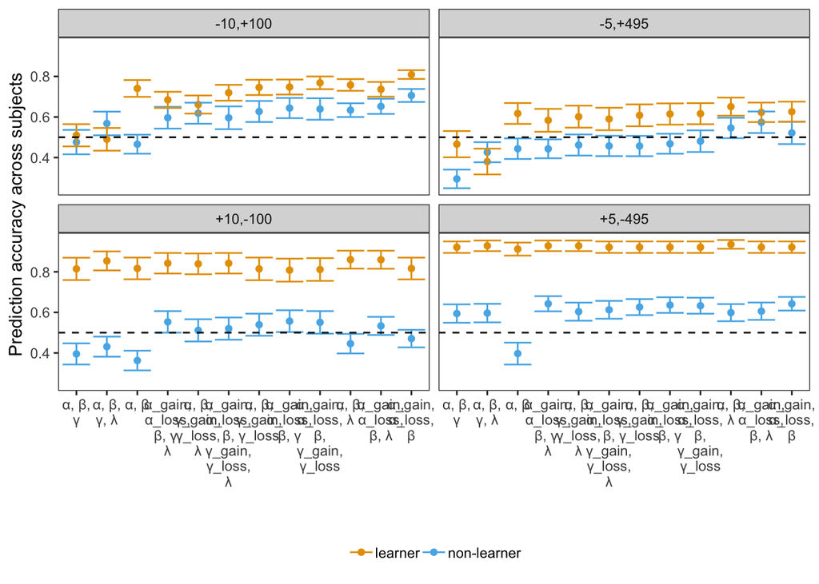

```r
all_sub_preds %>%
  mutate(pred_choice_1_0 = ifelse(choiceprob>0.5,1,0),
           act_choice_1_0 = ifelse(Response == 1, 1, ifelse(Response == 2, 0, NA)),
           pred_correct = ifelse(pred_choice_1_0 == act_choice_1_0, 1, 0)) %>%
    group_by(sub_id, learner, Trial_type, model) %>%
    summarise(cor_pred_prop = mean(pred_correct, na.rm=T)) %>%
  filter(!is.na(learner)) %>%
  ungroup()%>%
  group_by(learner, model, Trial_type) %>%
  summarise(ave_pred_prop = mean(cor_pred_prop),
            sem_pred_prop = sem(cor_pred_prop)) %>%
  ungroup() %>%
  mutate(model = gsub("Preds_", "", model))%>%
  left_join(num_pars_df %>%
              mutate(model = gsub("LearningParams_", "", model)) %>%
              select(-pars),
            by="model") %>%
  left_join(mean_pred_df %>%
              select(model, pred_order), by="model") %>%
  ungroup()%>%
  mutate(x_axis = factor(x_axis, levels=unique(x_axis[order(pred_order, x_axis)]), ordered=TRUE),
         learner = ifelse(learner == 1, "learner", "non-learner"),
         facet_labels =  ifelse(Trial_type == 1, "+5,-495", ifelse(Trial_type == 2, "-5,+495", ifelse(Trial_type == 3, "-10,+100", ifelse(Trial_type == 4, "+10,-100", NA))))) %>%
  ggplot(aes(factor(x_axis),ave_pred_prop, color=factor(learner)))+
  geom_point()+
  geom_errorbar(aes(ymin = ave_pred_prop-sem_pred_prop, ymax = ave_pred_prop+sem_pred_prop))+
  xlab("")+
  ylab("Prediction accuracy across subjects")+
  theme(panel.grid = element_blank(),
        legend.title = element_blank())+
  scale_x_discrete(labels = function(x) str_wrap(x, width=5))+
  geom_hline(yintercept = 0.5, linetype="dashed") +
  facet_wrap(~facet_labels)
```

The model type by learner type interaction is not significant but the main effects are. Models that do not distinguish between gains and losses in either the learning rates or the the value exponents have lower prediction accuracies. Non-learners also have lower predictiona accuracies compared to learners.

```r
tmp = ave_sub_preds %>%
  mutate(no_gain_loss = ifelse(model %in% c("Fit_alpha-beta-exp_Fix_lossave_", "Fit_alpha-beta-exp-lossave_Fix_", "Fit_alpha-beta_Fix_exp-lossave_"), 1, 0))

m = lmer(cor_pred_prop ~ no_gain_loss*factor(learner) + (1|sub_id), tmp)
summary(m)
```

```
Linear mixed model fit by REML ['lmerMod']
Formula: cor_pred_prop ~ no_gain_loss * factor(learner) + (1 | sub_id)
   Data: tmp

REML criterion at convergence: -1017.7

Scaled residuals:
    Min      1Q  Median      3Q     Max
-4.3593 -0.3776  0.0476  0.5645  3.0855

Random effects:
 Groups   Name        Variance Std.Dev.
 sub_id   (Intercept) 0.01762  0.1327
 Residual             0.01434  0.1197
Number of obs: 883, groups:  sub_id, 74

Fixed effects:
                              Estimate Std. Error t value
(Intercept)                    0.55554    0.02251  24.685
no_gain_loss                  -0.11482    0.01299  -8.840
factor(learner)1               0.16893    0.03225   5.238
no_gain_loss:factor(learner)1  0.01494    0.01859   0.804

Correlation of Fixed Effects:
            (Intr) n_gn_l fct()1
no_gain_lss -0.147
fctr(lrnr)1 -0.698  0.103
n_gn_ls:()1  0.103 -0.699 -0.145
```

```r
confint.merMod(m)
```

```
Computing profile confidence intervals ...
```

```
                                    2.5 %      97.5 %
.sig01                         0.11083970  0.15663822
.sigma                         0.11399949  0.12567098
(Intercept)                    0.51147065  0.59960636
no_gain_loss                  -0.14028087 -0.08936636
factor(learner)1               0.10578022  0.23207889
no_gain_loss:factor(learner)1 -0.02149504  0.05138972
```

Comparing the prediction accuracies of the models that do distinguish between gains and losses in either the learning rates or the exponents we do not find any differences among them. The learner group main effect shows up in this model as well.

```r
summary(lm(cor_pred_prop ~ model+learner, tmp %>% filter(no_gain_loss == 0)))
```

```
Call:
lm(formula = cor_pred_prop ~ model + learner, data = tmp %>%
    filter(no_gain_loss == 0))

Residuals:
    Min      1Q  Median      3Q     Max
-0.5859 -0.1183  0.0240  0.1179  0.3784

Coefficients:
                                                                Estimate
(Intercept)                                                     0.582557
modelFit_alpha_neg-alpha_pos-beta-exp_Fix_lossave_             -0.025184
modelFit_alpha_neg-alpha_pos-beta-exp_neg-exp_pos_Fix_lossave_ -0.019815
modelFit_alpha_neg-alpha_pos-beta-exp_neg-exp_pos-lossave_Fix_ -0.045418
modelFit_alpha_neg-alpha_pos-beta-exp-lossave_Fix_             -0.049870
modelFit_alpha_neg-alpha_pos-beta-lossave_Fix_exp_             -0.001911
modelFit_alpha-beta-exp_neg-exp_pos_Fix_lossave_               -0.033364
modelFit_alpha-beta-exp_neg-exp_pos-lossave_Fix_               -0.049827
modelFit_alpha-beta-lossave_Fix_exp_                           -0.010108
learner                                                         0.168078
                                                               Std. Error
(Intercept)                                                      0.020305
modelFit_alpha_neg-alpha_pos-beta-exp_Fix_lossave_               0.027305
modelFit_alpha_neg-alpha_pos-beta-exp_neg-exp_pos_Fix_lossave_   0.027398
modelFit_alpha_neg-alpha_pos-beta-exp_neg-exp_pos-lossave_Fix_   0.027398
modelFit_alpha_neg-alpha_pos-beta-exp-lossave_Fix_               0.027305
modelFit_alpha_neg-alpha_pos-beta-lossave_Fix_exp_               0.027398
modelFit_alpha-beta-exp_neg-exp_pos_Fix_lossave_                 0.027398
modelFit_alpha-beta-exp_neg-exp_pos-lossave_Fix_                 0.027398
modelFit_alpha-beta-lossave_Fix_exp_                             0.027305
learner                                                          0.012923
                                                               t value
(Intercept)                                                     28.690
modelFit_alpha_neg-alpha_pos-beta-exp_Fix_lossave_              -0.922
modelFit_alpha_neg-alpha_pos-beta-exp_neg-exp_pos_Fix_lossave_  -0.723
modelFit_alpha_neg-alpha_pos-beta-exp_neg-exp_pos-lossave_Fix_  -1.658
modelFit_alpha_neg-alpha_pos-beta-exp-lossave_Fix_              -1.826
modelFit_alpha_neg-alpha_pos-beta-lossave_Fix_exp_              -0.070
modelFit_alpha-beta-exp_neg-exp_pos_Fix_lossave_                -1.218
modelFit_alpha-beta-exp_neg-exp_pos-lossave_Fix_                -1.819
```

[output cut: 15 more lines]

```
modelFit_alpha_neg-alpha_pos-beta-exp_Fix_lossave_
modelFit_alpha_neg-alpha_pos-beta-exp_neg-exp_pos_Fix_lossave_
modelFit_alpha_neg-alpha_pos-beta-exp_neg-exp_pos-lossave_Fix_ .
modelFit_alpha_neg-alpha_pos-beta-exp-lossave_Fix_             .
modelFit_alpha_neg-alpha_pos-beta-lossave_Fix_exp_
modelFit_alpha-beta-exp_neg-exp_pos_Fix_lossave_
modelFit_alpha-beta-exp_neg-exp_pos-lossave_Fix_               .
modelFit_alpha-beta-lossave_Fix_exp_
learner                                                        ***
---
Signif. codes:  0 '***' 0.001 '**' 0.01 '*' 0.05 '.' 0.1 ' ' 1

Residual standard error: 0.1661 on 651 degrees of freedom
Multiple R-squared:  0.2141,    Adjusted R-squared:  0.2032
F-statistic: 19.71 on 9 and 651 DF,  p-value: < 2.2e-16
```

## Differing conclusions

Comparing prediction accuracy of left out data eliminates only 3 of 12 models but does not allow us to distinguish between the remaining ones. Since the literature does not point to one model over the others strongly either we compare the parameter estimates from each of the remaining 9 models between learners and non-learners to see whether they tell the same story on the behavioral difference.

```r
models = unique(best_sub_pars$model)[unique(best_sub_pars$model) %in% c("Fit_alpha-beta-exp_Fix_lossave_", "Fit_alpha-beta-exp-lossave_Fix_", "Fit_alpha-beta_Fix_exp-lossave_")==FALSE]

learner_diff_df = data.frame(model = NA, par = NA, learner=NA)

for(i in 1:length(models)){
  cur_data = best_sub_pars %>% filter(model == models[i])
  cur_data = cur_data %>% select(learner, contains("xopt"))
  cur_data = cur_data[,colSums(is.na(cur_data))<nrow(cur_data)]
  cur_data = transform_remove_skew(cur_data, verbose=FALSE)
  names(cur_data)[1] = "learner"
  pars = names(cur_data)[!names(cur_data) %in% c("learner")]

    for(j in 1:length(pars)){
      p_vals = summary(lm(cur_data[,pars[j]] ~ cur_data[,"learner"]))$coefficients['cur_data[, "learner"]','Pr(>|t|)']
      learner_diff_df[nrow(learner_diff_df) + 1,] = list(models[i],pars[j], p_vals[1])
    }
}
learner_diff_df = learner_diff_df[-1,]

learner_diff_df %>%
  mutate(learner_adjust = p.adjust(learner), method="fdr")%>%
  filter(learner<0.05)
```

| model | par | learner | learner_adjust | method |
| --- | --- | --- | --- | --- |
| Fit_alpha_neg-alpha_pos-beta_Fix_exp-lossave_ | xopt_alpha_pos | 1.031193e-07 | 3.402938e-06 | fdr |
| Fit_alpha_neg-alpha_pos-beta_Fix_exp-lossave_ | xopt_alpha_neg.logTr | 8.904347e-03 | 2.048000e-01 | fdr |
| Fit_alpha_neg-alpha_pos-beta_Fix_exp-lossave_ | xopt_beta.logTr | 5.266754e-05 | 1.369356e-03 | fdr |
| Fit_alpha_neg-alpha_pos-beta-exp_Fix_lossave_ | xopt_alpha_pos | 1.267993e-02 | 2.535986e-01 | fdr |
| Fit_alpha_neg-alpha_pos-beta-exp_Fix_lossave_ | xopt_exp | 2.351089e-12 | 9.169246e-11 | fdr |
| Fit_alpha_neg-alpha_pos-beta-exp_Fix_lossave_ | xopt_alpha_neg.logTr | 8.966284e-03 | 2.048000e-01 | fdr |
| Fit_alpha_neg-alpha_pos-beta-exp_neg-exp_pos_Fix_lossave_ | xopt_exp_neg | 5.030812e-09 | 1.760784e-07 | fdr |
| Fit_alpha_neg-alpha_pos-beta-exp_neg-exp_pos_Fix_lossave_ | xopt_exp_pos | 5.743368e-06 | 1.550709e-04 | fdr |
| Fit_alpha_neg-alpha_pos-beta-exp_neg-exp_pos-lossave_Fix_ | xopt_exp_neg.logTr | 5.449012e-07 | 1.743684e-05 | fdr |
| Fit_alpha_neg-alpha_pos-beta-exp_neg-exp_pos-lossave_Fix_ | xopt_exp_pos.logTr | 2.547213e-06 | 7.386919e-05 | fdr |

[output cut: 11 more lines]

```r
#Helper functions for plot coloring
tmp = num_pars_df %>%
  mutate(model = gsub("LearningParams_", "", model)) %>%
  select(model, x_axis)

fct_brdr_clrs = learner_diff_df %>%
  mutate(learner_adjust = p.adjust(learner), method="fdr")%>%
  select(model, par, learner, learner_adjust) %>%
  mutate(fct_brdr = ifelse(learner<0.5, "purple", NA),
         fct_brdr = ifelse(learner_adjust<0.5, "red", fct_brdr)) %>%
  left_join(tmp, by="model") %>%
  select(par, x_axis, fct_brdr) %>%
  mutate(par = gsub(".logTr", "", par))
```

```r
#Create df with transformed parameter estimates for plotting since the transformed distributions were used in checking for group differences.

log_lookup = best_sub_pars %>%
  select(sub_id, model, contains("xopt"), x_axis, learner) %>%
  gather(key, value, -sub_id, -model, -x_axis, -learner) %>%
  group_by(model, key) %>%
  summarise(skw = skew(value)) %>%
  filter(abs(skw)>1) %>%
  arrange(model)

best_sub_pars_trans = data.frame()

for(i in 1:length(models)){
  cur_model = models[i]
  cur_model_data = best_sub_pars %>% filter(model == cur_model)
  cur_skw_vars = log_lookup %>% filter(model == cur_model)

  for(j in 1:nrow(cur_skw_vars)){
    cur_model_data[,cur_skw_vars$key[j]] = pos_log(cur_model_data[,cur_skw_vars$key[j]])
  }

  best_sub_pars_trans = rbind.all.columns(best_sub_pars_trans, cur_model_data)
}
```

The differences listed above are visualized below. Red outlines survive multiple comparisons. Purple outlines are significant in isolation but don’t survive multiple comparisons.

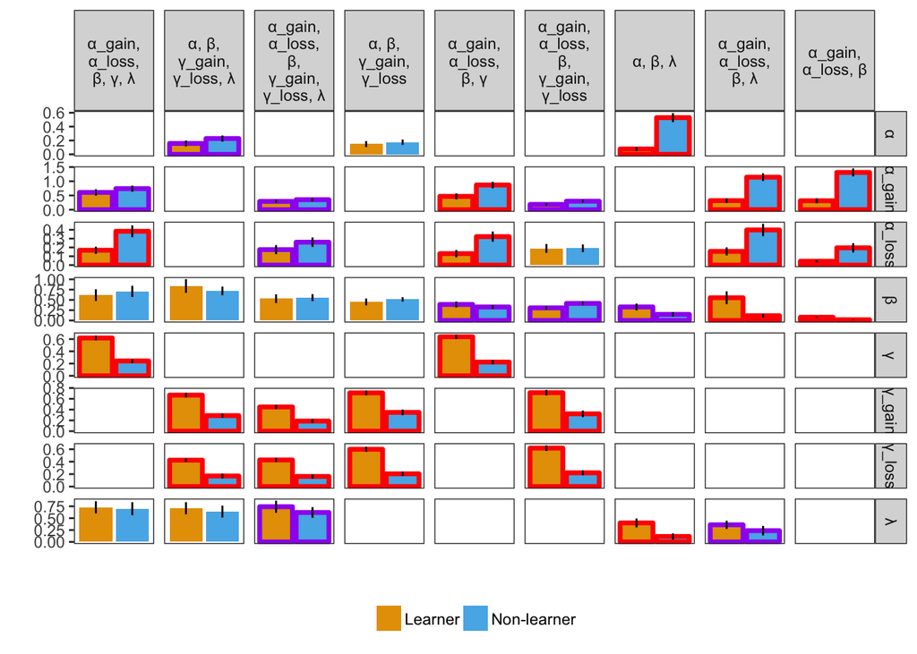

```r
best_sub_pars_trans %>%
  select(contains("xopt"), "sub_id", "x_axis", "learner") %>%
  gather(key, value, -learner, -sub_id, -x_axis) %>%
  mutate(par=key,
         key = ifelse(key == "xopt_alpha", "\u03b1", ifelse(key == "xopt_beta", "\u03b2", ifelse(key == "xopt_exp", "\u03b3", ifelse(key == "xopt_alpha_pos", "\u03b1_gain", ifelse(key == "xopt_alpha_neg", "\u03b1_loss",ifelse(key == "xopt_exp_pos", "\u03b3_gain", ifelse(key == "xopt_exp_neg", "\u03b3_loss", ifelse(key == "xopt_lossave", "\u03bb", NA)))))))))%>%
  group_by(learner, x_axis, key, par) %>%
  summarise(mean_val = mean(value,na.rm=T),
            sem_val = sem(value)) %>%
  left_join(fct_brdr_clrs, by=c("par", "x_axis")) %>%
  ungroup()%>%
  mutate(learner = factor(ifelse(learner == 1, "Learner", "Non-learner"), levels = c("Learner", "Non-learner"))) %>%
  left_join(mean_pred_df %>%
              select(x_axis, pred_order), by="x_axis") %>%
  mutate(x_axis = factor(x_axis, levels=unique(x_axis[order(pred_order, x_axis)]), ordered=TRUE)) %>%
    ggplot(aes(learner, mean_val))+
    geom_bar(aes(fill=learner, color=fct_brdr), stat="identity",size=1.25)+
    geom_errorbar(aes(ymin=mean_val-sem_val, ymax=mean_val+sem_val), width=0)+
  facet_grid(key~x_axis, scales='free', labeller = label_wrap_gen(10))+
  ylab("")+
  xlab("")+
  theme(panel.grid = element_blank(),
        axis.text.x = element_blank(),
        axis.ticks.x = element_blank(),
        legend.title=element_blank())+
  scale_color_manual(values=c("purple", "red", NA))+
  guides(color=FALSE)
```

```r
ggsave("RL_par_diffs_all.jpeg", device = "jpeg", path = fig_path, width = 10, height = 8, units = "in", dpi = 450)
```

## Model similarity

The remaining 9 models are indistinguishable from each by predictive accuracy. They also offer different narratives with respect to the behavioral difference observed between the two learner groups.

We can quantify how similar the models are to each other at a finer scale (instead of the aggregate scale of average choice prediction) by comparing the prediction errors and expected values generated by the models to each other.

### RPE correlations

The motivation for this comparison came from the difficulty in choosing the RPE regressor for the imaging analyses. Since the models were not different from each in other metrics we wondered whether we could average RPEs from them without loosing information and possibly getting a more informative regressor.

```r
input_path = '/Users/zeynepenkavi/Dropbox/PoldrackLab/DevStudy_Analyses/input/'

preds = list.files(path=paste0(input_path, "rl_preds/"), pattern = "All")

all_mods_preds = data.frame()
all_mods_pes = data.frame()

for(f in preds){
  data = read.csv(paste0(input_path, "rl_preds/", f))
  all_mods_preds = rbind.all.columns(all_mods_preds,data.frame(data))
  data = data %>% select(PE, sub_id, X, model)
  names(data)[which(names(data)=="PE")] = paste0("PE_",unique(data$model))
  data = data %>% select(-model)
  if(nrow(all_mods_pes)==0){
    all_mods_pes = data
  }
  else{
    all_mods_pes = all_mods_pes %>%
      left_join(data, by=c("sub_id", "X"))
  }
}

all_mods_pes = all_mods_pes %>%
  select(X, sub_id, everything())
```

```r
mods = grep("PE", names(all_mods_pes), value=T)
cor_df = data.frame(sub_id = NA, var1 = NA, var2=NA, cor_val=NA)
for(i in 1:(length(mods) - 1) ){
  rem_mods = mods[-c(1:i)]

  for(j in 1:length(rem_mods)){
    cur_data = all_mods_pes %>% select(sub_id, mods[i], rem_mods[j])

    cur_cor_df = cur_data %>%
      group_by(sub_id) %>%
      do(data.frame(Cor=t(cor(.[,2], .[,3], use="pairwise")))) %>%
      mutate(var1 = mods[i],
             var2 = rem_mods[j]) %>%
      select(sub_id, var1, var2, everything())

    names(cur_cor_df) = c("sub_id", "var1", "var2", "cor_val")

    cor_df = rbind(cor_df, data.frame(cur_cor_df))

  }
}

cor_df = cor_df[-1,]
```

Distributuons of correlations between PE’s generated by different models for each subject (sorted by the median correlation for model pair)

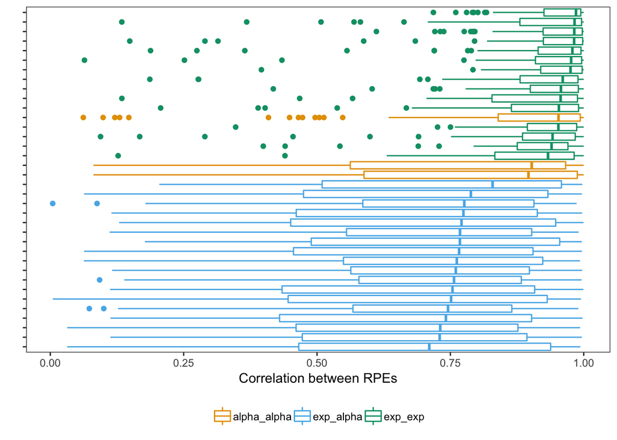

```r
tmp = num_pars_df %>%
  mutate(model = gsub("LearningParams_", "", model)) %>%
  select(model, x_axis)

exp_models = c("Fit_alpha-beta-exp_neg-exp_pos-lossave_Fix_",
               "Fit_alpha-beta-exp_neg-exp_pos_Fix_lossave_",
               "Fit_alpha_neg-alpha_pos-beta-exp_neg-exp_pos_Fix_lossave_",
               "Fit_alpha_neg-alpha_pos-beta-exp_neg-exp_pos-lossave_Fix_",
               "Fit_alpha_neg-alpha_pos-beta-exp-lossave_Fix_",
               "Fit_alpha_neg-alpha_pos-beta-exp_Fix_lossave_")

cor_df %>%
  mutate(var1 = gsub("PE_Preds_", "", var1),
         var2 = gsub("PE_Preds_", "", var2)) %>%
  filter(var1 %in% models) %>%
  filter(var2 %in% models) %>%
  left_join(tmp, by=c("var1"="model")) %>%
  left_join(tmp, by=c("var2"="model")) %>%
  mutate(cor_btw = paste0(x_axis.x, " VS. ", x_axis.y)) %>%
  group_by(cor_btw) %>%
  mutate(med_cor_val = median(cor_val, na.rm=T),
         cor_type = ifelse((var1 %in% exp_models)&(var2 %in% exp_models), "exp_exp", ifelse(!(var1 %in% exp_models)&!(var2 %in% exp_models), "alpha_alpha", "exp_alpha"))) %>%
  #exp_exp, alpha-alpha, "exp_alpha"
  ggplot(aes(reorder(cor_btw,med_cor_val), cor_val, color=factor(cor_type)))+
  geom_boxplot()+
  theme(#axis.text.x = element_text(angle=90),
    axis.text.y = element_blank(),
        legend.title = element_blank(),
        panel.grid = element_blank())+
  ylab("Correlation between RPEs")+
  xlab("")+
  coord_flip()
```

```r
ggsave("PE_corrs.jpeg", device = "jpeg", path = fig_path, width = 3, height = 5, units = "in", dpi = 450)
```

Predicted RPEs from models with exponents are more similar to each other compared to RPEs predicted by models without exponents.

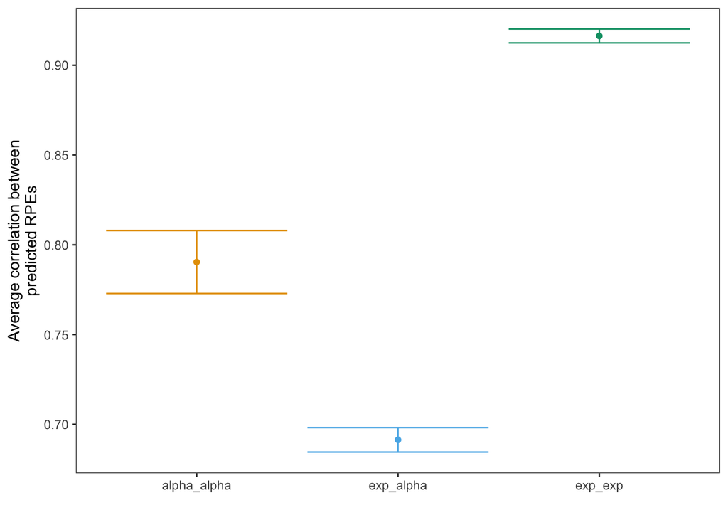

```r
cor_df %>%
  mutate(var1 = gsub("PE_Preds_", "", var1),
         var2 = gsub("PE_Preds_", "", var2)) %>%
  filter(var1 %in% models) %>%
  filter(var2 %in% models) %>%
  left_join(tmp, by=c("var1"="model")) %>%
  left_join(tmp, by=c("var2"="model")) %>%
  mutate(cor_btw = paste0(x_axis.x, " VS. ", x_axis.y)) %>%
  group_by(cor_btw) %>%
  mutate(med_cor_val = median(cor_val, na.rm=T),
         cor_type = ifelse((var1 %in% exp_models)&(var2 %in% exp_models), "exp_exp", ifelse(!(var1 %in% exp_models)&!(var2 %in% exp_models), "alpha_alpha", "exp_alpha"))) %>%
  ungroup() %>%
  group_by(cor_type) %>%
  summarise(mean_cor = mean(cor_val, na.rm=T),
            sem_cor = sem(cor_val)) %>%
  ggplot(aes(cor_type, mean_cor, col=cor_type))+
  geom_point()+
  geom_errorbar(aes(ymin = mean_cor-sem_cor, ymax = mean_cor+sem_cor))+
  xlab("")+
  ylab("Average correlation between\npredicted RPEs")+
  theme(panel.grid = element_blank(),
        legend.position="none")
```

Since we have multiple models that generate RPEs that we cannot distinguish from each other behaviorally we can try to **distinguish them using the brain data** by looking at whether the RPEs generated by any of them correlate more highly with the brain data (in the apriori region vStr).

### EV correlations

```r
all_mods_evs = all_mods_preds %>%
  select(X, EV, sub_id, model) %>%
  mutate(model = paste0("EV_", model)) %>%
  spread(model, EV)
```

```r
mods = grep("EV", names(all_mods_evs), value=T)
cor_df = data.frame(sub_id = NA, var1 = NA, var2=NA, cor_val=NA)
for(i in 1:(length(mods) - 1) ){
  rem_mods = mods[-c(1:i)]

  for(j in 1:length(rem_mods)){
    cur_data = all_mods_evs %>% select(sub_id, mods[i], rem_mods[j])

    cur_cor_df = cur_data %>%
      group_by(sub_id) %>%
      do(data.frame(Cor=t(cor(.[,2], .[,3], use="pairwise")))) %>%
      mutate(var1 = mods[i],
             var2 = rem_mods[j]) %>%
      select(sub_id, var1, var2, everything())

    names(cur_cor_df) = c("sub_id", "var1", "var2", "cor_val")

    cor_df = rbind(cor_df, data.frame(cur_cor_df))

  }
}

cor_df = cor_df[-1,]
```

Distributuons of correlations between EV’s generated by different models for each subject (sorted by the median correlation for model pair)

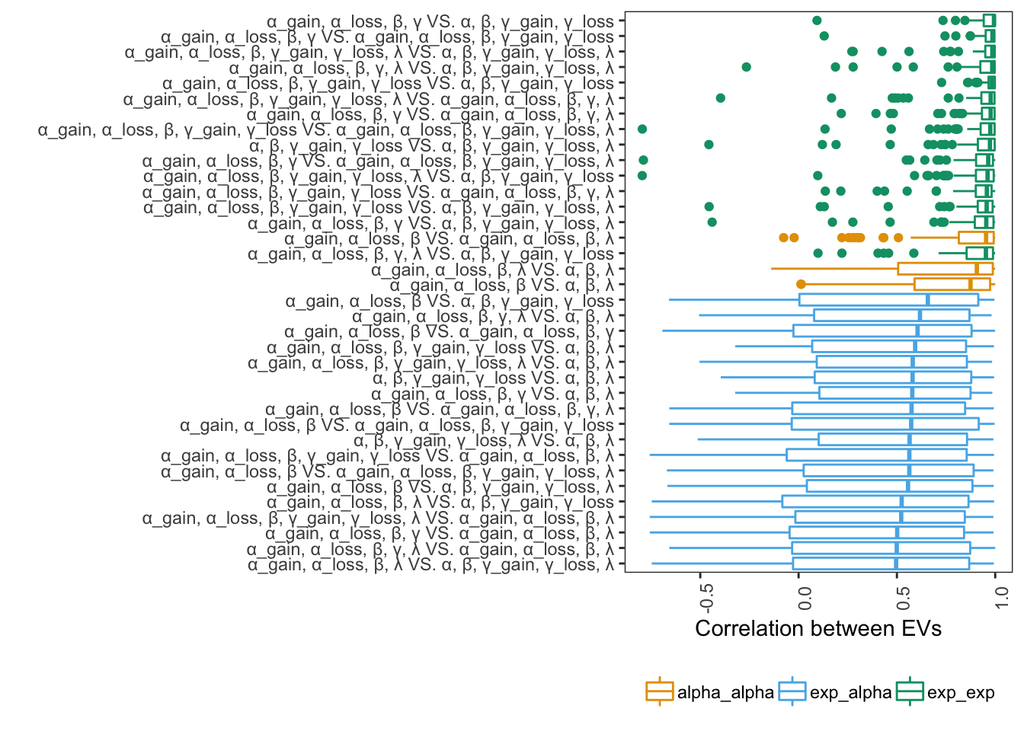

```r
tmp = num_pars_df %>%
  mutate(model = gsub("LearningParams_", "", model)) %>%
  select(model, x_axis)

exp_models = c("Fit_alpha-beta-exp_neg-exp_pos-lossave_Fix_",
               "Fit_alpha-beta-exp_neg-exp_pos_Fix_lossave_",
               "Fit_alpha_neg-alpha_pos-beta-exp_neg-exp_pos_Fix_lossave_",
               "Fit_alpha_neg-alpha_pos-beta-exp_neg-exp_pos-lossave_Fix_",
               "Fit_alpha_neg-alpha_pos-beta-exp-lossave_Fix_",
               "Fit_alpha_neg-alpha_pos-beta-exp_Fix_lossave_")

cor_df %>%
  mutate(var1 = gsub("EV_Preds_", "", var1),
         var2 = gsub("EV_Preds_", "", var2)) %>%
  filter(var1 %in% models) %>%
  filter(var2 %in% models) %>%
  left_join(tmp, by=c("var1"="model")) %>%
  left_join(tmp, by=c("var2"="model")) %>%
  mutate(cor_btw = paste0(x_axis.x, " VS. ", x_axis.y)) %>%
  group_by(cor_btw) %>%
  mutate(med_cor_val = median(cor_val, na.rm=T),
         cor_type = ifelse((var1 %in% exp_models)&(var2 %in% exp_models), "exp_exp", ifelse(!(var1 %in% exp_models)&!(var2 %in% exp_models), "alpha_alpha", "exp_alpha"))) %>%
  #exp_exp, alpha-alpha, "exp_alpha"
  ggplot(aes(reorder(cor_btw,med_cor_val), cor_val, color=factor(cor_type)))+
  geom_boxplot()+
  theme(axis.text.x = element_text(angle=90),
        legend.title = element_blank(),
        panel.grid = element_blank())+
  ylab("Correlation between EVs")+
  xlab("")+
  coord_flip()
```

```r
ggsave("EV_corrs.jpeg", device = "jpeg", path = fig_path, width = 7, height = 6, units = "in", dpi = 450)
```

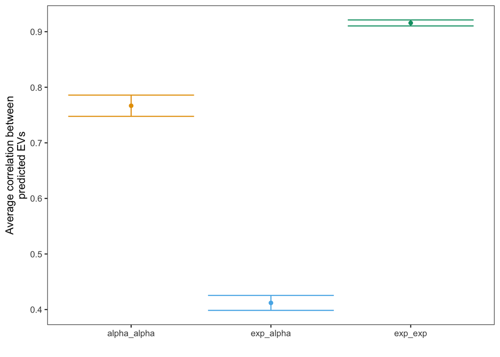

```r
cor_df %>%
  mutate(var1 = gsub("EV_Preds_", "", var1),
         var2 = gsub("EV_Preds_", "", var2)) %>%
  filter(var1 %in% models) %>%
  filter(var2 %in% models) %>%
  left_join(tmp, by=c("var1"="model")) %>%
  left_join(tmp, by=c("var2"="model")) %>%
  mutate(cor_btw = paste0(x_axis.x, " VS. ", x_axis.y)) %>%
  group_by(cor_btw) %>%
  mutate(med_cor_val = median(cor_val, na.rm=T),
         cor_type = ifelse((var1 %in% exp_models)&(var2 %in% exp_models), "exp_exp", ifelse(!(var1 %in% exp_models)&!(var2 %in% exp_models), "alpha_alpha", "exp_alpha"))) %>%
  ungroup() %>%
  group_by(cor_type) %>%
  summarise(mean_cor = mean(cor_val, na.rm=T),
            sem_cor = sem(cor_val)) %>%
  ggplot(aes(cor_type, mean_cor, col=cor_type))+
  geom_point()+
  geom_errorbar(aes(ymin = mean_cor-sem_cor, ymax = mean_cor+sem_cor))+
  xlab("")+
  ylab("Average correlation between\npredicted EVs")+
  theme(panel.grid = element_blank(),
        legend.position="none")
```

## Brain correlations

```r
all_vstr_pe_betas = read.csv(paste0(input_path, 'rpe_cors/all_vstr_pe_betas.csv'))
```

Predicted RPEs for which model or average of three model types correlate highest with brain activity (i.e. have the highest betas)?  
Note = when comparing the models looking at absolute betas to get a sense of the ‘strength’ of the relationship.

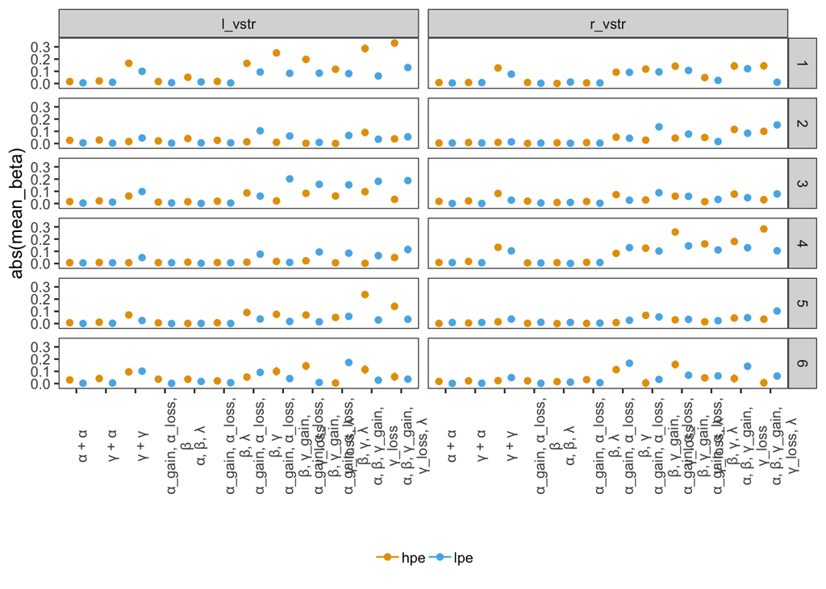

```r
tmp_levels = c("α + α", "γ + α" ,"γ + γ" ,"α_gain, α_loss, β" , "α, β, λ","α_gain, α_loss, β, λ","α_gain, α_loss, β, γ" ,"α_gain, α_loss, β, γ_gain, γ_loss", "α_gain, α_loss, β, γ_gain, γ_loss, λ", "α_gain, α_loss, β, γ, λ" , "α, β, γ_gain, γ_loss", "α, β, γ_gain, γ_loss, λ"  )

all_vstr_pe_betas %>%
  filter(pe_type != 'pe') %>%
 filter(abs(beta) < 10) %>%
  group_by(roi, run_num, model, pe_type) %>%
  summarise(mean_beta = mean(beta),
            sem_beta = sem(beta)) %>%
  left_join(num_pars_df %>%
              select(model, x_axis) %>%
              mutate(model = gsub("LearningParams_", "", model)),
            by = "model") %>%
  mutate(x_axis = ifelse(model == "alpha_alpha", "\u03b1 + \u03b1", ifelse(model == "exp_exp", "\u03b3 + \u03b3", ifelse(model == "exp_alpha", "\u03b3 + \u03b1", x_axis))),
         x_axis = factor(x_axis, levels=tmp_levels)) %>%
  ggplot(aes(x_axis, abs(mean_beta), color=pe_type))+
  geom_point(position=position_dodge(width = 0.9))+
  geom_errorbar(aes(ymin = abs(mean_beta) - sem_beta, ymax = abs(mean_beta) + sem_beta), position=position_dodge(width = 0.9), width=0.1)+
  facet_grid(run_num~roi)+
  theme(axis.text.x = element_text(angle = 90),
        panel.grid = element_blank(),
        legend.title = element_blank())+
  xlab("")+
  scale_x_discrete(labels = function(x) str_wrap(x, width=15))
```

```r
ggsave("PE_betas.jpeg", device = "jpeg", path = fig_path, width = 12, height = 6, units = "in", dpi = 450)
```

Looking only at the averages of three model types since there isn’t a clear winner from the individiaul model correlations between predicted RPEs and brain activity and they were indistinguishable behaviorally as well.

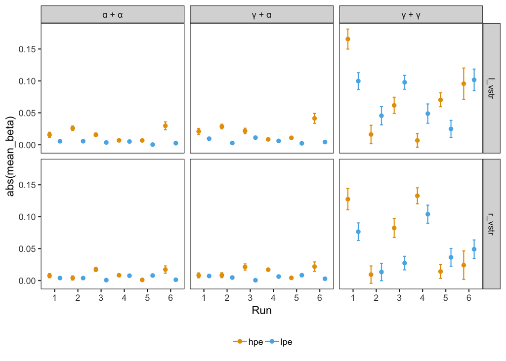

```r
all_vstr_pe_betas %>%
  filter(pe_type != 'pe') %>%
 filter(abs(beta) < 10) %>%
  group_by(roi, run_num, model, pe_type) %>%
  summarise(mean_beta = mean(beta),
            sem_beta = sem(beta)) %>%
  left_join(num_pars_df %>%
              select(model, x_axis) %>%
              mutate(model = gsub("LearningParams_", "", model)),
            by = "model") %>%
  mutate(x_axis = ifelse(model == "alpha_alpha", "\u03b1 + \u03b1", ifelse(model == "exp_exp", "\u03b3 + \u03b3", ifelse(model == "exp_alpha", "\u03b3 + \u03b1", x_axis))),
         x_axis = factor(x_axis, levels=tmp_levels)) %>%
  filter(model %in% c("exp_exp", "alpha_alpha", "exp_alpha")) %>%
  ggplot(aes(factor(run_num), abs(mean_beta), color=pe_type))+
  geom_point(position=position_dodge(width = 0.9))+
  geom_errorbar(aes(ymin = abs(mean_beta) - sem_beta, ymax = abs(mean_beta) + sem_beta), position=position_dodge(width = 0.9), width=0.25)+
  facet_grid(roi~x_axis)+
  theme(panel.grid = element_blank(),
        legend.title = element_blank())+
  xlab("Run")
```

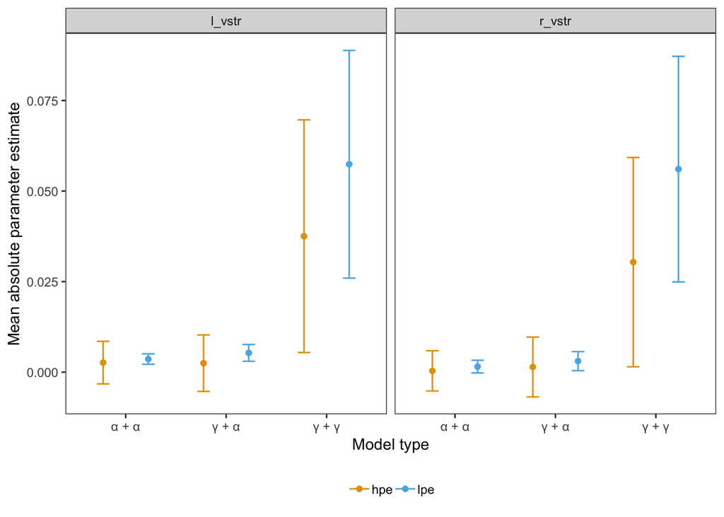

```r
all_vstr_pe_betas %>%
  filter(pe_type != 'pe') %>%
 filter(abs(beta) < 10) %>%
  left_join(num_pars_df %>%
              select(model, x_axis) %>%
              mutate(model = gsub("LearningParams_", "", model)),
            by = "model") %>%
  mutate(x_axis = ifelse(model == "alpha_alpha", "\u03b1 + \u03b1", ifelse(model == "exp_exp", "\u03b3 + \u03b3", ifelse(model == "exp_alpha", "\u03b3 + \u03b1", x_axis))),
         x_axis = factor(x_axis, levels=tmp_levels)) %>%
  filter(model %in% c("exp_exp", "alpha_alpha", "exp_alpha")) %>%
  group_by(sub_num, roi, x_axis, pe_type) %>%
  summarise(mean_beta = mean(beta)) %>%
  group_by(roi, x_axis, pe_type) %>%
  summarise(sem_beta = sem(mean_beta),
            mean_beta = mean(mean_beta)) %>%
  ggplot(aes(x_axis, abs(mean_beta), color=pe_type))+
  geom_point(position=position_dodge(width = 0.9))+
  geom_errorbar(aes(ymin = abs(mean_beta) - sem_beta, ymax = abs(mean_beta) + sem_beta), position=position_dodge(width = 0.9), width=0.25)+
  facet_grid(.~roi)+
  theme(panel.grid = element_blank(),
        legend.title = element_blank())+
  xlab("Model type")+
  ylab("Mean absolute parameter estimate")
```

```r
ggsave("PE_betas_3_types.jpeg", device = "jpeg", path = fig_path, width = 3, height = 4, units = "in", dpi = 450)
```

RPEs from the averaging of exp_exp models have higher correlations with brain activity. Particularly for lpe’s.

```r
tmp=all_vstr_pe_betas %>%
  filter(pe_type != 'pe') %>%
 filter(abs(beta) < 10) %>%
  left_join(num_pars_df %>%
              select(model, x_axis) %>%
              mutate(model = gsub("LearningParams_", "", model)),
            by = "model") %>%
  mutate(x_axis = ifelse(model == "alpha_alpha", "\u03b1 + \u03b1", ifelse(model == "exp_exp", "\u03b3 + \u03b3", ifelse(model == "exp_alpha", "\u03b3 + \u03b1", x_axis))),
         x_axis = factor(x_axis, levels=tmp_levels)) %>%
  filter(model %in% c("exp_exp", "alpha_alpha", "exp_alpha"))
```

```r
summary(lmer(abs(beta) ~ pe_type*model+(1|sub_num), tmp))
```

```
Linear mixed model fit by REML ['lmerMod']
Formula: abs(beta) ~ pe_type * model + (1 | sub_num)
   Data: tmp

REML criterion at convergence: 648455.4

Scaled residuals:
    Min      1Q  Median      3Q     Max
-2.6405 -0.4373 -0.0029  0.2052 17.3342

Random effects:
 Groups   Name        Variance Std.Dev.
 sub_num  (Intercept) 0.04365  0.2089
 Residual             0.29516  0.5433
Number of obs: 400535, groups:  sub_num, 72

Fixed effects:
                           Estimate Std. Error t value
(Intercept)                0.058260   0.024713   2.357
pe_typelpe                -0.021431   0.002971  -7.213
modelexp_alpha             0.026848   0.002986   8.992
modelexp_exp               0.468434   0.002993 156.493
pe_typelpe:modelexp_alpha -0.006519   0.004200  -1.552
pe_typelpe:modelexp_exp   -0.027040   0.004209  -6.425

Correlation of Fixed Effects:
                (Intr) p_typl mdlxp_l mdlxp_x p_typlp:mdlxp_l
pe_typelpe      -0.061
modelxp_lph     -0.060  0.503
modelexp_xp     -0.060  0.501  0.499
p_typlp:mdlxp_l  0.043 -0.707 -0.711  -0.355
p_typlp:mdlxp_x  0.043 -0.705 -0.355  -0.711   0.499
```

### Learner differences in brain correlations

RPEs from the averaging of exp_exp models are also more variablein these correlations. Is this because these correlations can discriminate between learner/not-learner groups?

Two points from the graph below: - The learner vs non-learner difference seems to lie in the hpe response between the two groups.  
- If one wanted to make a model selection point from this too would a positive response for both hpe/lpe as seen in exp_exp models be more convincing than the 0 response in the alpha_alpha models?

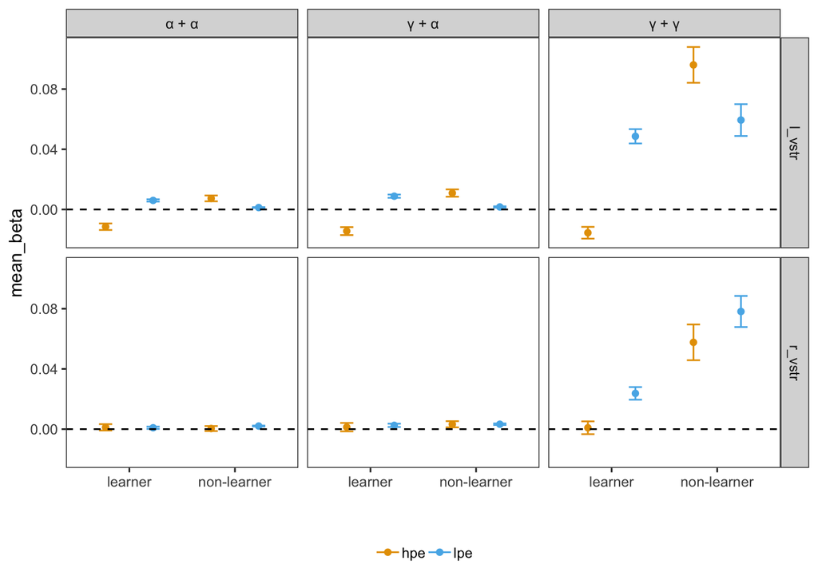

```r
all_vstr_pe_betas %>%
  filter(pe_type != 'pe') %>%
 filter(abs(beta) < 10) %>%
  left_join(num_pars_df %>%
              select(model, x_axis) %>%
              mutate(model = gsub("LearningParams_", "", model)),
            by = "model") %>%
  mutate(x_axis = ifelse(model == "alpha_alpha", "\u03b1 + \u03b1", ifelse(model == "exp_exp", "\u03b3 + \u03b3", ifelse(model == "exp_alpha", "\u03b3 + \u03b1", x_axis))),
         x_axis = factor(x_axis, levels=tmp_levels)) %>%
  filter(model %in% c("exp_exp", "exp_alpha", "alpha_alpha")) %>%
  left_join(learner_info %>% rename(sub_num = sub_id), by = "sub_num") %>%
  group_by(roi, pe_type, learner, x_axis) %>%
   summarise(mean_beta = mean(beta),
            sem_beta = sem(beta)) %>%
  ungroup() %>%
  mutate(learner = ifelse(learner == 1, "learner", "non-learner")) %>%
  ggplot(aes(learner, mean_beta, color=pe_type))+
  geom_point(position=position_dodge(width = 0.9))+
  geom_errorbar(aes(ymin = mean_beta - sem_beta, ymax = mean_beta + sem_beta), position=position_dodge(width = 0.9), width=0.25)+
   facet_grid(roi~x_axis)+
  theme(panel.grid = element_blank(),
        legend.title = element_blank())+
  xlab("")+
  geom_hline(aes(yintercept=0), linetype="dashed")
```

```r
tmp = all_vstr_pe_betas %>%
  filter(pe_type != 'pe') %>%
 filter(abs(beta) < 10) %>%
  left_join(num_pars_df %>%
              select(model, x_axis) %>%
              mutate(model = gsub("LearningParams_", "", model)),
            by = "model") %>%
  mutate(x_axis = ifelse(model == "alpha_alpha", "\u03b1 + \u03b1", ifelse(model == "exp_exp", "\u03b3 + \u03b3", ifelse(model == "exp_alpha", "\u03b3 + \u03b1", x_axis))),
         x_axis = factor(x_axis, levels=tmp_levels)) %>%
  filter(model %in% c("exp_exp", "exp_alpha", "alpha_alpha")) %>%
  left_join(learner_info %>% rename(sub_num = sub_id), by = "sub_num") %>%
  mutate(learner = ifelse(learner == 1, "learner", "non-learner"))
```

With exp_exp models the interaction between learner and pe_type is significant in the l_vstr

```r
summary(lmer(beta ~ learner*pe_type + (1|sub_num), tmp %>% filter(roi == "l_vstr" & model == "exp_exp")))
```

```
Linear mixed model fit by REML ['lmerMod']
Formula: beta ~ learner * pe_type + (1 | sub_num)
   Data: tmp %>% filter(roi == "l_vstr" & model == "exp_exp")

REML criterion at convergence: 198520.7

Scaled residuals:
     Min       1Q   Median       3Q      Max
-10.2776  -0.1633  -0.0005   0.1518   9.2523

Random effects:
 Groups   Name        Variance Std.Dev.
 sub_num  (Intercept) 0.04376  0.2092
 Residual             1.15763  1.0759
Number of obs: 66430, groups:  sub_num, 72

Fixed effects:
                              Estimate Std. Error t value
(Intercept)                   -0.01539    0.03588  -0.429
learnernon-learner             0.11152    0.05074   2.198
pe_typelpe                     0.06418    0.01179   5.444
learnernon-learner:pe_typelpe -0.09883    0.01672  -5.911

Correlation of Fixed Effects:
            (Intr) lrnrn- p_typl
lrnrnn-lrnr -0.707
pe_typelpe  -0.168  0.119
lrnrnn-lr:_  0.119 -0.167 -0.705
```

```r
summary(lmer(beta ~ learner*pe_type + (1|sub_num), tmp %>% filter(roi == "r_vstr" & model == "exp_exp")))
```

```
Linear mixed model fit by REML ['lmerMod']
Formula: beta ~ learner * pe_type + (1 | sub_num)
   Data: tmp %>% filter(roi == "r_vstr" & model == "exp_exp")

REML criterion at convergence: 196497.3

Scaled residuals:
     Min       1Q   Median       3Q      Max
-10.1497  -0.1689  -0.0060   0.1531   9.9190

Random effects:
 Groups   Name        Variance Std.Dev.
 sub_num  (Intercept) 0.03416  0.1848
 Residual             1.12822  1.0622
Number of obs: 66329, groups:  sub_num, 72

Fixed effects:
                                Estimate Std. Error t value
(Intercept)                    0.0007952  0.0319137   0.025
learnernon-learner             0.0619894  0.0451349   1.373
pe_typelpe                     0.0240209  0.0116391   2.064
learnernon-learner:pe_typelpe -0.0007143  0.0165201  -0.043

Correlation of Fixed Effects:
            (Intr) lrnrn- p_typl
lrnrnn-lrnr -0.707
pe_typelpe  -0.187  0.132
lrnrnn-lr:_  0.132 -0.186 -0.705
```

With alpha_alpha models the interaction between learner and pe_type is significant in the l_vstr

```r
summary(lmer(beta ~ learner*pe_type + (1|sub_num), tmp %>% filter(roi == "l_vstr" & model == "alpha_alpha")))
```

```
Linear mixed model fit by REML ['lmerMod']
Formula: beta ~ learner * pe_type + (1 | sub_num)
   Data: tmp %>% filter(roi == "l_vstr" & model == "alpha_alpha")

REML criterion at convergence: -30724.9

Scaled residuals:
    Min      1Q  Median      3Q     Max
-33.454  -0.063   0.001   0.063  39.667

Random effects:
 Groups   Name        Variance  Std.Dev.
 sub_num  (Intercept) 0.0006783 0.02604
 Residual             0.0368655 0.19200
Number of obs: 66943, groups:  sub_num, 72

Fixed effects:
                               Estimate Std. Error t value
(Intercept)                   -0.012061   0.004595  -2.625
learnernon-learner             0.019341   0.006495   2.978
pe_typelpe                     0.018021   0.002103   8.568
learnernon-learner:pe_typelpe -0.024110   0.002972  -8.112

Correlation of Fixed Effects:
            (Intr) lrnrn- p_typl
lrnrnn-lrnr -0.707
pe_typelpe  -0.235  0.166
lrnrnn-lr:_  0.166 -0.232 -0.708
```

but not in the r_vstr.

```r
summary(lmer(beta ~ learner*pe_type + (1|sub_num), tmp %>% filter(roi == "r_vstr" & model == "alpha_alpha")))
```

```
Linear mixed model fit by REML ['lmerMod']
Formula: beta ~ learner * pe_type + (1 | sub_num)
   Data: tmp %>% filter(roi == "r_vstr" & model == "alpha_alpha")

REML criterion at convergence: -39913.2

Scaled residuals:
    Min      1Q  Median      3Q     Max
-28.916  -0.057  -0.002   0.062  35.651

Random effects:
 Groups   Name        Variance  Std.Dev.
 sub_num  (Intercept) 0.0005864 0.02422
 Residual             0.0321380 0.17927
Number of obs: 66945, groups:  sub_num, 72

Fixed effects:
                                Estimate Std. Error t value
(Intercept)                    0.0010479  0.0042748   0.245
learnernon-learner            -0.0006351  0.0060423  -0.105
pe_typelpe                    -0.0003240  0.0019638  -0.165
learnernon-learner:pe_typelpe  0.0019754  0.0027749   0.712

Correlation of Fixed Effects:
            (Intr) lrnrn- p_typl
lrnrnn-lrnr -0.707
pe_typelpe  -0.235  0.167
lrnrnn-lr:_  0.167 -0.233 -0.708
```

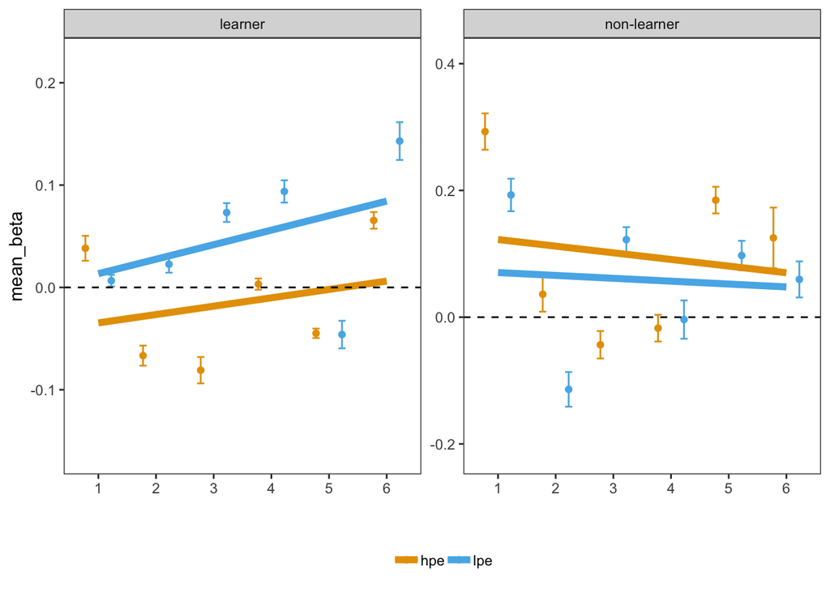

```r
all_vstr_pe_betas %>%
  filter(pe_type != 'pe') %>%
 filter(abs(beta) < 10) %>%
  left_join(num_pars_df %>%
              select(model, x_axis) %>%
              mutate(model = gsub("LearningParams_", "", model)),
            by = "model") %>%
  mutate(x_axis = ifelse(model == "alpha_alpha", "\u03b1 + \u03b1", ifelse(model == "exp_exp", "\u03b3 + \u03b3", ifelse(model == "exp_alpha", "\u03b3 + \u03b1", x_axis))),
         x_axis = factor(x_axis, levels=tmp_levels)) %>%
  filter(model %in% c("exp_exp")) %>%
  left_join(learner_info %>% rename(sub_num = sub_id), by = "sub_num") %>%
  group_by(run_num, roi, pe_type, learner, x_axis) %>%
   summarise(mean_beta = mean(beta),
            sem_beta = sem(beta)) %>%
  ungroup() %>%
  mutate(learner = ifelse(learner == 1, "learner", "non-learner")) %>%
  filter(roi == "l_vstr") %>%
  ggplot(aes(factor(run_num), mean_beta, color=pe_type))+
  geom_point(position=position_dodge(width = 0.9))+
  geom_errorbar(aes(ymin = mean_beta - sem_beta, ymax = mean_beta + sem_beta), position=position_dodge(width = 0.9), width=0.25)+
  geom_line(stat='smooth', method='lm', aes(group=pe_type), size=2, span=0.5)+
  facet_wrap(~learner, scales='free')+
  theme(panel.grid = element_blank(),
        legend.title = element_blank())+
  xlab("")+
  geom_hline(aes(yintercept=0), linetype="dashed")
```

**Overall the case for exp_exp seems models is stronger:**  
- The RPEs from these models correlate more strongly with brain activity  
- This relationship shows more fluctuation across the task (though these fluctuations are difficult to describe and interpret)  
- They discriminate between learners and non-learners better.

In terms of clarifying the confusing picture in the literature using exp models has pros and cons. Since they haven’t been used in this line of research before the models are not directly comparable. But they take into account a wealth of other literature on value processing and with a single parameter extend RL models to account for known differences in value distortion particularly with respect to the domain (gain vs loss). It also provides an answer for the behavioral difference between the learner groups in this new parameter which could provide a partial reason for why the previous results were not compatible with each other.